# P-Value

Bruno

25/09/2019

# Definições

Hipótese nula: uma afirmação que não traz novidades quando comparada a uma hipótese alternativa que postula algum grau de novidade, no contexto de um teste de significância (Everitt and Skrondal 2010).

P-Value: a probabilidade de dados observados apresentarem uma estatística de falta de aderência à hipótese nula tão ou mais extrema que a observada, considerando que estams em um universo onde a hipótese nula é verdadeira (Everitt and Skrondal 2010).

Formalmente:

$$P(T(y^{rep}) > T(y)|H)$$

Onde $H$ é a hipótese nula, $T()$ é uma função que calcula a aderência dos dados a $H$, $y$ são os dados usados no experimento analisado e $y^{rep}$ são dados vindos de uma replicação hipotética do experimento (Gelman 2013).

# Erro de interpretação mais comum

O erro de interpretação mais comum é considerar que o número representado pelo P-Value é a probabilidade de a hipótese nula ser verdadeira (Everitt and Skrondal 2010).

Isso não é verdade: a hipótese nula é verdadeira ou não, e isso é um fato determinístico sobre o universo. Só que é um fato não observável.

Os óculos do cientista para avaliar se a hipótese é verdadeira são os dados do experimento, e eles mostram uma imagem estocástica imperfeita: se o cientista der azar, eles podem mostrar uma imagem enganosa, ou seja:

- Uma aderência baixa dos dados à hipótese nula quando ela é verdadeira: Erro Tipo I
- Uma aderência alta à hipótese nula quando a hipótese nula é falsa: Erro Tipo II

Nada disso muda nada a respeito da validade da hipótese.

# 20 William Bonners

Imagine que dois candidatos a presidente estão empatados entre os eleitores e as pesquisas eleitorais são perfeitamente configuradas para uma margem de erro de 2% a um nível de tolerância de 95%.

De 20 William Bonners de universos paralelos onde a amostra da pesquisa foi sorteada, um deles vai dizer erroneamente que um candidato está na frente do outro fora da margem de erro.

[figure not shown]

# Outro erro de interpretação

“Um P-value muito pequeno é igual a um efeito considerável”

# Por que 0,05?

> “The value for which P=0.05, or 1 in 20, is 1.96 or nearly 2; it is convenient to take this point as a limit in judging whether a deviation ought to be considered significant or not. Deviations exceeding twice the standard deviation are thus formally regarded as significant. Using this criterion we should be led to follow up a false indication only once in 22 trials, even if the statistics were the only guide available. Small effects will still escape notice if the data are insufficiently numerous to bring them out, but no lowering of the standard of significance would meet this difficulty.”(Fisher 1925)

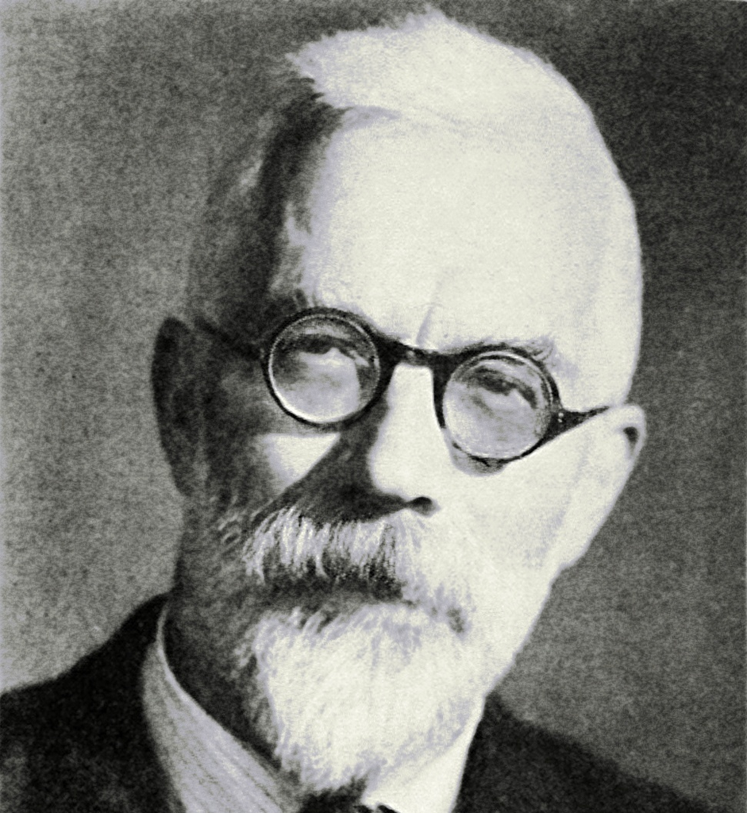

Esse senhor respeitável, Sir Ronald Fisher, pai da estatística moderna achou o número de 0,05 pro P-Value bonitinho e conveniente pois significava 2 desvios-padrão no caso de uma variavel com distribuição normal.

Até hoje o pessoal se fixou nisso

# Tudo ou nada

[figure not shown]

# O único objetivo a ser buscado

E existência de um objetivo tão importante assim acaba embotando os cientistas, que consideram que, atingido o objetivo, não é necessário fazer muita análise adicional antes de publicar

[figure not shown]

Os autores do artigo (Decety et al. 2015) foram descuidados com a sua análise, usando uma variável categórica como se fosse numérica.

# Malandrão

O artigo (Simmons, Nelson, and Simonsohn 2011) denuncia e batiza uma prática chamada P-Hacking. As inúmeras opções de coleta de dados, análise e comunicação dos resultados leva a taxa de falsos positivos baseados em P-Value a níveis altíssimos

Algumas soluções são propostas, como coletar dados antes de analisar, listar todas as variáveis tocadas durante o estudo (inclusive as que falharam), reportar a análise com a variável e sem a variável de interesse mas mantendo todas as outras.

# O labirinto de labirintos

> “Pensé en un laberinto de laberintos, en un sinuoso laberinto creciente que abarcara el pasado y el porvenir y que implicara de algún modo los astros. Absorto en esas ilusorias imágenes, olvidé mi destino de perseguido. Me sentí, por un tiempo indeterminado, percibidor abstracto del mundo”(Borges 1941)

# Referências

Borges, J. L. 1941. “Ficciones.”

Decety, Jean, Jason M Cowell, Kang Lee, Randa Mahasneh, Susan Malcolm-Smith, Bilge Selcuk, and Xinyue Zhou. 2015. “The Negative Association Between Religiousness and Children’s Altruism Across the World.” *Current Biology* 25 (22): 2951–5.

Everitt, Brian S, and Anders Skrondal. 2010. *The Cambridge Dictionary of Statistics*. New York University.

Fisher, Ronald Aylmer. 1925. “Statistical Methods for Research Workers.” In *Breakthroughs in Statistics*, 66–70. Springer.

Gelman, Andrew. 2013. “Commentary: P Values and Statistical Practice.” *Epidemiology* 24 (1): 69–72.

Simmons, Joseph P, Leif D Nelson, and Uri Simonsohn. 2011. “False-Positive Psychology: Undisclosed Flexibility in Data Collection and Analysis Allows Presenting Anything as Significant.” *Psychological Science* 22 (11): 1359–66.